# Исследование объявлений о продаже квартир

#### Определите факторы, которые больше всего влияют на общую (полную) стоимость объекта.

Изучите, зависит ли цена от:

- общей площади;
- жилой площади;
- площади кухни;
- количества комнат;
- этажа, на котором расположена квартира (первый, последний, другой);
- даты размещения (день недели, месяц, год).

Постройте графики, которые покажут зависимость цены от указанных выше параметров. Для подготовки данных перед визуализацией вы можете использовать сводные таблицы.

```python
data
```

|  | total_images | last_price | total_area | first_day_exposition | rooms | ceiling_height | floors_total | living_area | floor | studio | ... | ponds_around3000 | ponds_nearest | days_exposition | square_cost | weekday | month | year | floor_type | centers_range_km | price_kk |
| --- | --- | --- | --- | --- | --- | --- | --- | --- | --- | --- | --- | --- | --- | --- | --- | --- | --- | --- | --- | --- | --- |
| 0 | 20 | 13000000 | 108.00 | 2019-03-07 | 3 | 2.70 | 16 | 51.0 | 8 | False | ... | 2.0 | 755.0 | NaN | 120370.37 | четверг | март | 2019 | другой | 16.0 | 13.000 |
| 1 | 7 | 3350000 | 40.40 | 2018-12-04 | 1 | NaN | 11 | 18.6 | 1 | False | ... | 0.0 | -1.0 | 81.0 | 82920.79 | вторник | декабрь | 2018 | первый | 19.0 | 3.350 |
| 2 | 10 | 5196000 | 56.00 | 2015-08-20 | 2 | NaN | 5 | 34.3 | 4 | False | ... | 2.0 | 574.0 | 558.0 | 92785.71 | четверг | август | 2015 | другой | 14.0 | 5.196 |
| 3 | 0 | 64900000 | 159.00 | 2015-07-24 | 3 | NaN | 14 | NaN | 9 | False | ... | 3.0 | 234.0 | 424.0 | 408176.10 | пятница | июль | 2015 | другой | 7.0 | 64.900 |
| 4 | 2 | 10000000 | 100.00 | 2018-06-19 | 2 | 3.03 | 14 | 32.0 | 13 | False | ... | 1.0 | 48.0 | 121.0 | 100000.00 | вторник | июнь | 2018 | другой | 8.0 | 10.000 |
| ... | ... | ... | ... | ... | ... | ... | ... | ... | ... | ... | ... | ... | ... | ... | ... | ... | ... | ... | ... | ... | ... |
| 23694 | 9 | 9700000 | 133.81 | 2017-03-21 | 3 | 3.70 | 5 | 73.3 | 3 | False | ... | 3.0 | 381.0 | NaN | 72490.85 | вторник | март | 2017 | другой | 4.0 | 9.700 |
| 23695 | 14 | 3100000 | 59.00 | 2018-01-15 | 3 | NaN | 5 | 38.0 | 4 | False | ... | NaN | NaN | 45.0 | 52542.37 | понедельник | январь | 2018 | другой | -0.0 | 3.100 |
| 23696 | 18 | 2500000 | 56.70 | 2018-02-11 | 2 | NaN | 3 | 29.7 | 1 | False | ... | NaN | NaN | NaN | 44091.71 | воскресенье | февраль | 2018 | первый | -0.0 | 2.500 |
| 23697 | 13 | 11475000 | 76.75 | 2017-03-28 | 2 | 3.00 | 17 | NaN | 12 | False | ... | 3.0 | 196.0 | 602.0 | 149511.40 | вторник | март | 2017 | другой | 10.0 | 11.475 |
| 23698 | 4 | 1350000 | 32.30 | 2017-07-21 | 1 | 2.50 | 5 | 12.3 | 1 | False | ... | NaN | NaN | NaN | 41795.67 | пятница | июль | 2017 | первый | -0.0 | 1.350 |

23699 rows × 28 columns

```python
data_price = data_new.loc[:, ['price_kk', 'total_area', 'living_area', 'kitchen_area',
                              'rooms', 'floor_type', 'weekday', 'month', 'year']]
```

```python
data_price.head()
```

|  | price_kk | total_area | living_area | kitchen_area | rooms | floor_type | weekday | month | year |
| --- | --- | --- | --- | --- | --- | --- | --- | --- | --- |
| 0 | 13.000 | 108.0 | 51.0 | 25.0 | 3 | другой | четверг | март | 2019 |
| 1 | 3.350 | 40.4 | 18.6 | 11.0 | 1 | первый | вторник | декабрь | 2018 |
| 2 | 5.196 | 56.0 | 34.3 | 8.3 | 2 | другой | четверг | август | 2015 |
| 4 | 10.000 | 100.0 | 32.0 | 41.0 | 2 | другой | вторник | июнь | 2018 |
| 5 | 2.890 | 30.4 | 14.4 | 9.1 | 1 | другой | понедельник | сентябрь | 2018 |

Построим матрицу диаграмм рассеяния.

```
array([[<AxesSubplot:xlabel='price_kk', ylabel='price_kk'>,
        <AxesSubplot:xlabel='total_area', ylabel='price_kk'>,
        <AxesSubplot:xlabel='living_area', ylabel='price_kk'>,
        <AxesSubplot:xlabel='kitchen_area', ylabel='price_kk'>,
        <AxesSubplot:xlabel='rooms', ylabel='price_kk'>,
        <AxesSubplot:xlabel='year', ylabel='price_kk'>],
       [<AxesSubplot:xlabel='price_kk', ylabel='total_area'>,
        <AxesSubplot:xlabel='total_area', ylabel='total_area'>,
        <AxesSubplot:xlabel='living_area', ylabel='total_area'>,
        <AxesSubplot:xlabel='kitchen_area', ylabel='total_area'>,
        <AxesSubplot:xlabel='rooms', ylabel='total_area'>,
        <AxesSubplot:xlabel='year', ylabel='total_area'>],
       [<AxesSubplot:xlabel='price_kk', ylabel='living_area'>,
        <AxesSubplot:xlabel='total_area', ylabel='living_area'>,
        <AxesSubplot:xlabel='living_area', ylabel='living_area'>,
        <AxesSubplot:xlabel='kitchen_area', ylabel='living_area'>,
        <AxesSubplot:xlabel='rooms', ylabel='living_area'>,
        <AxesSubplot:xlabel='year', ylabel='living_area'>],
       [<AxesSubplot:xlabel='price_kk', ylabel='kitchen_area'>,
        <AxesSubplot:xlabel='total_area', ylabel='kitchen_area'>,
        <AxesSubplot:xlabel='living_area', ylabel='kitchen_area'>,
        <AxesSubplot:xlabel='kitchen_area', ylabel='kitchen_area'>,
        <AxesSubplot:xlabel='rooms', ylabel='kitchen_area'>,
        <AxesSubplot:xlabel='year', ylabel='kitchen_area'>],
       [<AxesSubplot:xlabel='price_kk', ylabel='rooms'>,
        <AxesSubplot:xlabel='total_area', ylabel='rooms'>,
        <AxesSubplot:xlabel='living_area', ylabel='rooms'>,
        <AxesSubplot:xlabel='kitchen_area', ylabel='rooms'>,
        <AxesSubplot:xlabel='rooms', ylabel='rooms'>,
        <AxesSubplot:xlabel='year', ylabel='rooms'>],
       [<AxesSubplot:xlabel='price_kk', ylabel='year'>,
        <AxesSubplot:xlabel='total_area', ylabel='year'>,
        <AxesSubplot:xlabel='living_area', ylabel='year'>,
        <AxesSubplot:xlabel='kitchen_area', ylabel='year'>,
        <AxesSubplot:xlabel='rooms', ylabel='year'>,
        <AxesSubplot:xlabel='year', ylabel='year'>]], dtype=object)
```

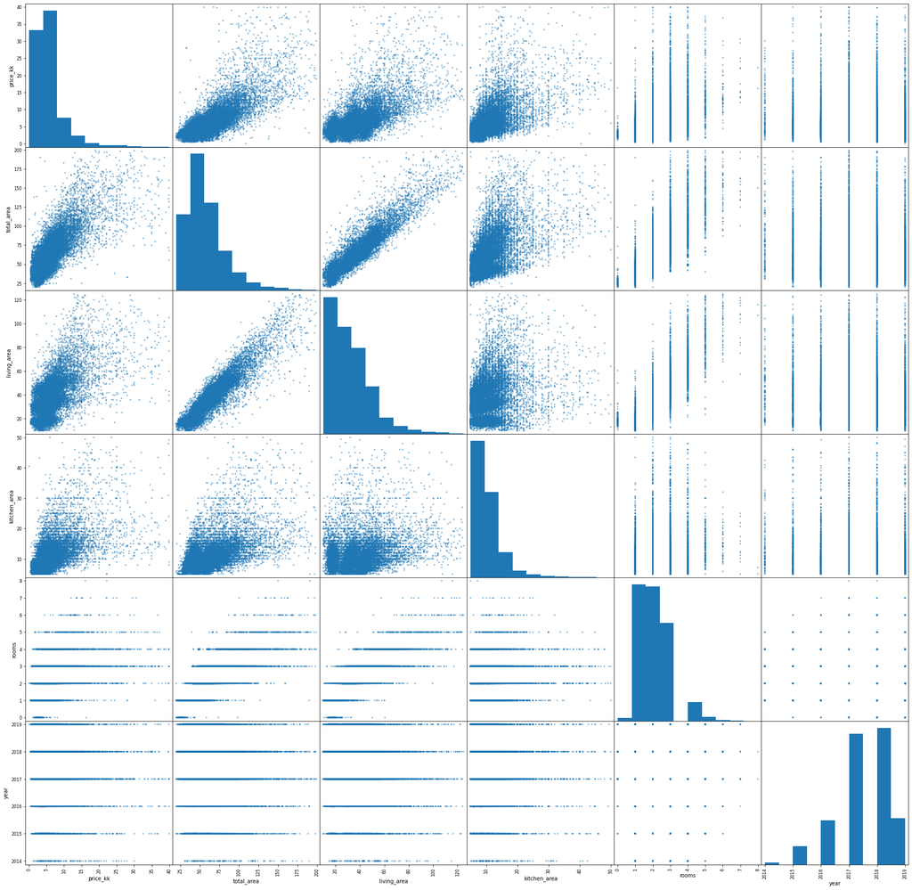

```python
pd.plotting.scatter_matrix(data_price, figsize=(30, 30))
```

Ну ёперный театр.

Ладно, меня уже так просто не сломать.

```
array([[<AxesSubplot:xlabel='price_kk', ylabel='price_kk'>,
        <AxesSubplot:xlabel='total_area', ylabel='price_kk'>,
        <AxesSubplot:xlabel='living_area', ylabel='price_kk'>,
        <AxesSubplot:xlabel='kitchen_area', ylabel='price_kk'>,
        <AxesSubplot:xlabel='rooms', ylabel='price_kk'>],
       [<AxesSubplot:xlabel='price_kk', ylabel='total_area'>,
        <AxesSubplot:xlabel='total_area', ylabel='total_area'>,
        <AxesSubplot:xlabel='living_area', ylabel='total_area'>,
        <AxesSubplot:xlabel='kitchen_area', ylabel='total_area'>,
        <AxesSubplot:xlabel='rooms', ylabel='total_area'>],
       [<AxesSubplot:xlabel='price_kk', ylabel='living_area'>,
        <AxesSubplot:xlabel='total_area', ylabel='living_area'>,
        <AxesSubplot:xlabel='living_area', ylabel='living_area'>,
        <AxesSubplot:xlabel='kitchen_area', ylabel='living_area'>,
        <AxesSubplot:xlabel='rooms', ylabel='living_area'>],
       [<AxesSubplot:xlabel='price_kk', ylabel='kitchen_area'>,
        <AxesSubplot:xlabel='total_area', ylabel='kitchen_area'>,
        <AxesSubplot:xlabel='living_area', ylabel='kitchen_area'>,
        <AxesSubplot:xlabel='kitchen_area', ylabel='kitchen_area'>,
        <AxesSubplot:xlabel='rooms', ylabel='kitchen_area'>],
       [<AxesSubplot:xlabel='price_kk', ylabel='rooms'>,
        <AxesSubplot:xlabel='total_area', ylabel='rooms'>,
        <AxesSubplot:xlabel='living_area', ylabel='rooms'>,
        <AxesSubplot:xlabel='kitchen_area', ylabel='rooms'>,
        <AxesSubplot:xlabel='rooms', ylabel='rooms'>]], dtype=object)
```

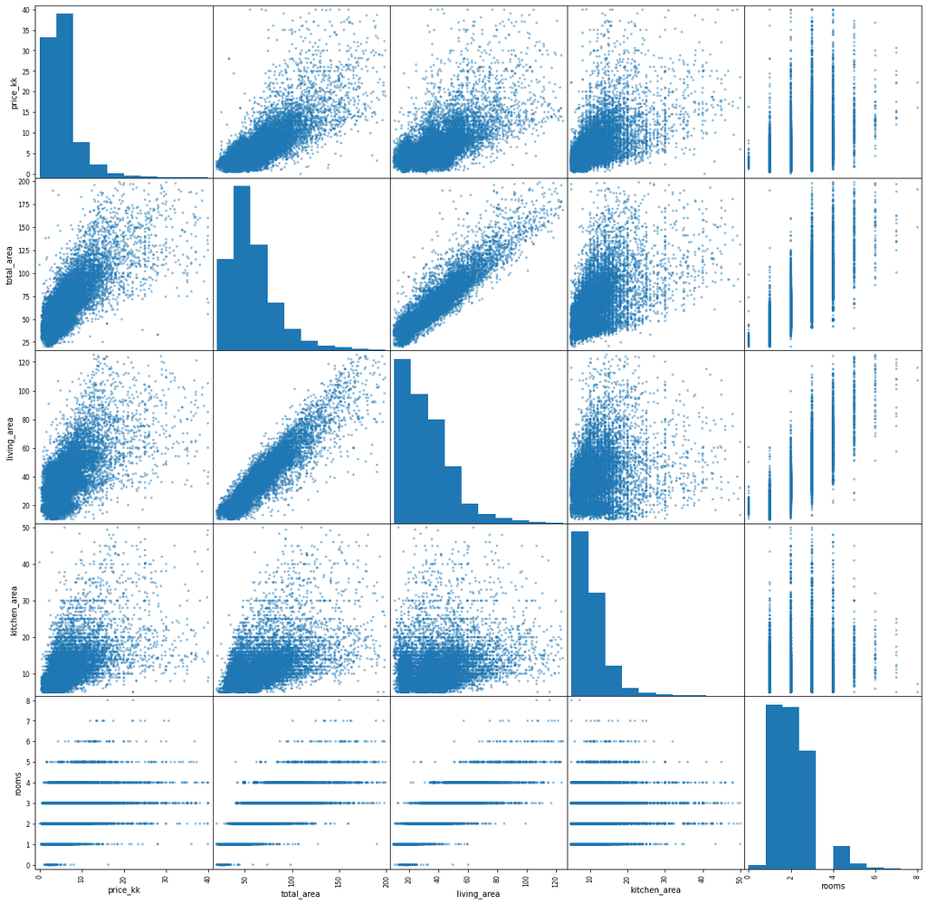

```python
pd.plotting.scatter_matrix(data_new[['price_kk', 'total_area', 'living_area', 'kitchen_area', 'rooms', 'floor_type']]
                           , figsize=(20, 20))
```

Блин, да, на что я надеялся, включая сюда floor_type, интересно. Пока самая сильная связь с total_area. Собственно, со всеми включенными параметрами есть явная связь. С rooms тоже явно есть, но метод визуализации не самый удачный.

```
array([[<AxesSubplot:xlabel='price_kk', ylabel='price_kk'>,
        <AxesSubplot:xlabel='year', ylabel='price_kk'>],
       [<AxesSubplot:xlabel='price_kk', ylabel='year'>,
        <AxesSubplot:xlabel='year', ylabel='year'>]], dtype=object)
```

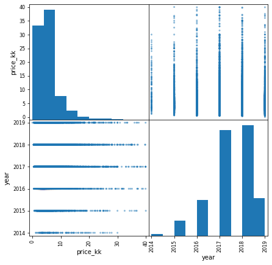

```python
pd.plotting.scatter_matrix(data_new[['price_kk', 'weekday', 'month', 'year']], figsize=(7, 7))
```

Ладно, не обязательно же всегда думать перед тем, как делаешь, да? Есть связь, years но зависимость нелинейная. Стабильный подъем до 2017-2018 годов и потом спад. Или же нет? Объявлений то сильно меньше. Поэтому и прокрашено плохо. И что нам с этим делать? Вот сейчас самое время подумать.

```python
data_price.corr()
```

|  | price_kk | total_area | living_area | kitchen_area | rooms | year |
| --- | --- | --- | --- | --- | --- | --- |
| price_kk | 1.000000 | 0.772594 | 0.660506 | 0.586235 | 0.477476 | -0.030711 |
| total_area | 0.772594 | 1.000000 | 0.924413 | 0.555772 | 0.790745 | -0.075678 |
| living_area | 0.660506 | 0.924413 | 1.000000 | 0.312948 | 0.878049 | -0.064594 |
| kitchen_area | 0.586235 | 0.555772 | 0.312948 | 1.000000 | 0.181169 | -0.048978 |
| rooms | 0.477476 | 0.790745 | 0.878049 | 0.181169 | 1.000000 | -0.043643 |
| year | -0.030711 | -0.075678 | -0.064594 | -0.048978 | -0.043643 | 1.000000 |

Как я и сказал, самая сильная связь с общей площадью (total_area). С годом в итоге очень слабая обратная связь. А выглядело всё иначе. То-то же. Сложно сказать, почему связь обратная. Может недвижимость подешевела. А может больше людей с менее дорогой жилплощадью стали её продавать.

Посмотрим связь с типом этажа.

```python
data_new.pivot_table(index='floor_type', values=['price_kk'],
                     aggfunc=['median', 'mean', 'count']).reset_index()
```

|  | floor_type | median price_kk | mean price_kk | count price_kk |
| --- | --- | --- | --- | --- |
| 0 | другой | 4.800 | 6.033823 | 16747 |
| 1 | неизвестно | 5.249 | 6.594444 | 81 |
| 2 | первый | 3.950 | 4.567777 | 2767 |
| 3 | последний | 4.250 | 5.487222 | 3151 |

Дороже всего стоят квартиры с неизвестным этажом. На втором месте другой. Первый оказался последним. Ха-ха-ха.

Посмотрим на дни недели.

```python
data_new.pivot_table(index='weekday', values=['price_kk'],
                     aggfunc=['median', 'mean', 'count']).reset_index()
```

|  | weekday | median price_kk | mean price_kk | count price_kk |
| --- | --- | --- | --- | --- |
| 0 | воскресенье | 4.55 | 5.666129 | 1629 |
| 1 | вторник | 4.70 | 5.741725 | 4027 |
| 2 | понедельник | 4.60 | 5.791299 | 3466 |
| 3 | пятница | 4.55 | 5.703069 | 3864 |
| 4 | среда | 4.68 | 5.894072 | 3811 |
| 5 | суббота | 4.55 | 5.596038 | 1853 |
| 6 | четверг | 4.60 | 5.912780 | 4096 |

Реже всего объявления добавляют на выходных. Это все выводы, которые нам следует сделать из этой таблицы.

Теперь посмотрим связь с месяцем.

```python
data_new.pivot_table(index='month', values=['price_kk'],
                     aggfunc=['median', 'mean', 'count']).reset_index()
```

|  | month | median price_kk | mean price_kk | count price_kk |
| --- | --- | --- | --- | --- |
| 0 | август | 4.560 | 5.857026 | 1683 |
| 1 | апрель | 4.780 | 5.784410 | 2282 |
| 2 | декабрь | 4.680 | 5.831071 | 1565 |
| 3 | июль | 4.600 | 5.754225 | 1623 |
| 4 | июнь | 4.400 | 5.597253 | 1694 |
| 5 | май | 4.500 | 5.812328 | 1230 |
| 6 | март | 4.650 | 5.725737 | 2477 |
| 7 | ноябрь | 4.650 | 5.900285 | 2275 |
| 8 | октябрь | 4.550 | 5.650210 | 2056 |
| 9 | сентябрь | 4.675 | 5.882764 | 1904 |
| 10 | февраль | 4.600 | 5.767907 | 2519 |
| 11 | январь | 4.600 | 5.845656 | 1438 |

Ох, проиндексировать бы это по порядку месяцов.

Ладно, в общем. Больше всего любят выставлять к весне. С февраля по апрель прям много, потом на мае резкий провал. Осень тоже плотная, с сентября по ноябрь. Ну и ещё, чем больше объявлений в месяце, тем немного выше цены. Интересно было бы это сравнить с тем, как покупают квартиры по месяцам.

Год тоже глянем напоследок.

```python
data_new.pivot_table(index='year', values=['price_kk'],
                     aggfunc=['median', 'mean', 'count']).reset_index()
```

[output not shown]

В 2014 слишком мало данных, не берём в расчёт. Я не хочу описывать всё. Скажу так. У средней цены до 2019 явное падение. Она потянула за собой медиану. Скорее всего и правда стали продавать больше недорогих квартир и это сместило общую массу значений. Не похоже, чтобы жильё дешевело, скорее наоборот.

**Итого.** Цена за квартиру имеет высокую прямую зависимость от общей площади квариры, а также среднюю прямую зависимость от числа комнат. Это значит, что чем выше площадь квартиры, тем выше цена за нее. Чем больше комнат, тем выше цена. Также если квартира находится на первом или последнем этаже, то ее стоимость ниже. Стоимость квартиры не зависит от дня недели публикации. Но немного зависит от месяца.

```python
data_new.pivot_table(index='year', values=['price_kk', 'total_area'],
                     aggfunc=['median', 'mean', 'count']).reset_index()
```

|  | year | median price_kk | median total_area | mean price_kk | mean total_area | count price_kk | count total_area |
| --- | --- | --- | --- | --- | --- | --- | --- |
| 0 | 2014 | 7.477 | 75.000 | 9.723807 | 80.969160 | 119 | 119 |
| 1 | 2015 | 5.200 | 59.000 | 6.650679 | 65.076250 | 1104 | 1104 |
| 2 | 2016 | 4.500 | 53.000 | 5.807142 | 59.157629 | 2661 | 2661 |
| 3 | 2017 | 4.500 | 51.135 | 5.671164 | 57.660901 | 7860 | 7860 |
| 4 | 2018 | 4.565 | 50.400 | 5.589891 | 56.201360 | 8218 | 8218 |
| 5 | 2019 | 5.010 | 51.400 | 6.123026 | 56.950841 | 2784 | 2784 |

Квартиры всё меньше.

#### Цена квадратного метра в 10 населённых пунктах с наибольшим числом объявлений

Посчитайте среднюю цену одного квадратного метра в 10 населённых пунктах с наибольшим числом объявлений — постройте сводную таблицу с количеством объявлений и средней ценой квадратного метра для этих населенных пунктов. Выделите населённые пункты с самой высокой и низкой стоимостью квадратного метра.

```python
data_new['locality_name'].value_counts().head(10)
```

```
Санкт-Петербург      15232
Мурино                 581
Кудрово                472
поселок Шушары         436
Всеволожск             396
Пушкин                 356
Колпино                334
поселок Парголово      319
Гатчина                302
Выборг                 235
Name: locality_name, dtype: int64
```

```python
top_10_locs = ['Санкт-Петербург', 'Мурино', 'Кудрово', 'поселок Шушары', 'Всеволожск',
               'Пушкин', 'Колпино', 'поселок Парголово', 'Гатчина', 'Выборг']
```

```python
data_new.query('locality_name == @top_10_locs').pivot_table(index='locality_name', values=('total_area', 'price_kk', 'square_cost'),
       aggfunc=['median', 'mean', 'count']).reset_index().sort_values(by=('median','square_cost'), ascending=False)
```

|  | locality_name | median price_kk | median square_cost | median total_area | mean price_kk | mean square_cost | mean total_area | count price_kk | count square_cost | count total_area |
| --- | --- | --- | --- | --- | --- | --- | --- | --- | --- | --- |
| 7 | Санкт-Петербург | 5.490 | 104251.845 | 54.30 | 6.928191 | 111375.337400 | 60.941864 | 15232 | 15232 | 15232 |
| 6 | Пушкин | 5.150 | 99865.715 | 53.00 | 6.092382 | 102913.258006 | 58.142697 | 356 | 356 | 356 |
| 4 | Кудрово | 3.890 | 95675.475 | 40.00 | 4.358689 | 95324.930508 | 46.395403 | 472 | 472 | 472 |
| 8 | поселок Парголово | 4.100 | 91516.560 | 42.90 | 4.455646 | 90209.996708 | 50.918401 | 319 | 319 | 319 |
| 5 | Мурино | 3.405 | 86119.400 | 37.70 | 3.691484 | 86012.196971 | 44.285663 | 581 | 581 | 581 |
| 9 | поселок Шушары | 3.950 | 76747.970 | 50.35 | 4.119553 | 78516.736972 | 54.018257 | 436 | 436 | 436 |
| 3 | Колпино | 3.600 | 74689.875 | 50.00 | 3.863353 | 75247.309491 | 52.367485 | 334 | 334 | 334 |
| 2 | Гатчина | 3.100 | 67925.850 | 45.60 | 3.503043 | 68846.422119 | 51.095629 | 302 | 302 | 302 |
| 0 | Всеволожск | 3.465 | 65789.470 | 53.55 | 3.791788 | 68621.569192 | 56.078359 | 396 | 396 | 396 |
| 1 | Выборг | 2.897 | 58158.320 | 50.20 | 3.243757 | 58140.851106 | 56.078979 | 235 | 235 | 235 |

Надо сравнить стоимость с площадью. Всё совпадаем с установленным порядком. Питер самый дорогой, Выборг самый дешёвый.

#### Стоимость квартир в Питере по удалённости от центра.

Ранее вы посчитали расстояние до центра в километрах. Теперь выделите квартиры в Санкт-Петербурге с помощью столбца locality_name и вычислите их среднюю стоимость на разном удалении от центра. Учитывайте каждый километр расстояния: узнайте среднюю цену квартир в одном километре от центра, в двух и так далее. Опишите, как стоимость объектов зависит от расстояния до центра города — постройте график изменения средней цены для каждого километра от центра Петербурга.

```python
data_spb = data_new.query('locality_name == "Санкт-Петербург"')
```

```python
data_spb.pivot_table(index='centers_range_km', values='price_kk', aggfunc='mean').sort_values(by='centers_range_km')
```

| centers_range_km | price_kk |
| --- | --- |
| -0.0 | 11.208038 |
| 1.0 | 12.079641 |
| 2.0 | 11.135828 |
| 3.0 | 9.681370 |
| 4.0 | 10.570031 |
| 5.0 | 11.017600 |
| 6.0 | 10.190862 |
| 7.0 | 10.506183 |
| 8.0 | 8.847796 |
| 9.0 | 6.858223 |
| 10.0 | 6.384820 |
| 11.0 | 6.122256 |
| 12.0 | 5.774808 |
| 13.0 | 6.062549 |
| 14.0 | 5.597547 |
| 15.0 | 5.789894 |
| 16.0 | 5.372317 |
| 17.0 | 5.184552 |
| 18.0 | 4.868167 |
| 19.0 | 5.048558 |
| 20.0 | 4.611579 |
| 21.0 | 5.489379 |
| 22.0 | 5.374091 |
| 23.0 | 4.689843 |
| 24.0 | 3.841296 |
| 25.0 | 4.052846 |
| 26.0 | 3.973038 |
| 27.0 | 8.300000 |
| 28.0 | 5.026429 |
| 29.0 | 4.236667 |
| 32.0 | 4.175000 |

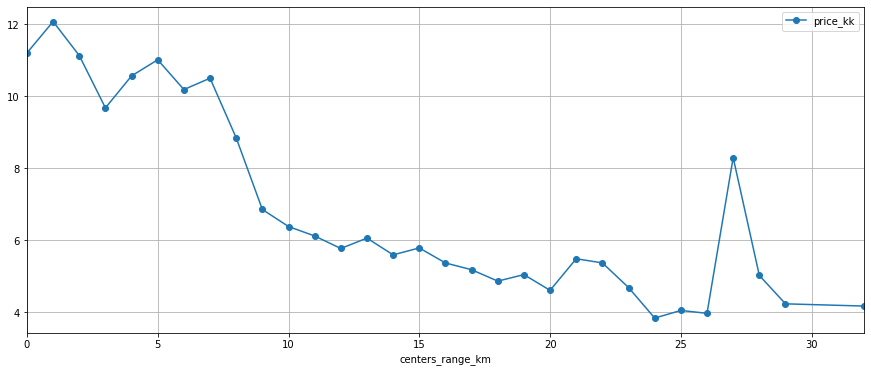

```python
data_spb.pivot_table(index='centers_range_km', values='price_kk',
                  aggfunc='mean').plot(y='price_kk', style='o-', xlim=(0, 32), grid=True, figsize=(15, 6))
```

Оказывается, оси х нельзя передавать индекс. Во всяком случае без reset_index. Зато он берёт его сам по умолчанию.

По графику мы видим, что в центре средняя цена держится на высоком уровне, хоть и колеблется от 12 до 10 млн. Колебания могут быть связаны с тем, что мы обрезали очень дорогие квартиры, что сместило среднее в центре. После 7 км от центра начинается резкий спад, но после 9 км он замедляется и становится плавным и стабильным. Также мы наблюдаем аномальный пик цены на точке в 27 км. Давайте изучим его.

```python
data_spb[data_spb['centers_range_km'] == 27][['last_price', 'total_area', 'living_area',
                                              'kitchen_area', 'rooms', 'square_cost']]
```

|  | last_price | total_area | living_area | kitchen_area | rooms | square_cost |
| --- | --- | --- | --- | --- | --- | --- |
| 748 | 14350000 | 74.0 | 30.0 | 25.0 | 2 | 193918.92 |
| 5961 | 2250000 | 32.0 | 16.5 | 7.0 | 1 | 70312.50 |

Всего 2 квартиры. Одна дешёвая, а вторая ну очень дорогая. Особенно для такой удалённости. Дороже, чем средняя квартира в центре. Это статистически нормально. Она большая, в ней 2 комнаты и огромная кухня (возможно кухня-зал/гостиная). Скорее всего очень хорошая квартира. Возможно в дорогом доме - цена квадратного метра тоже вышла почти в 2 раза выше средней по Питеру. В общем, просто небольшая аномалия, ничего такого.

# Общий вывод

**Чек-лист готовности проекта**

Поставьте 'x' в выполненных пунктах. Далее нажмите Shift+Enter.

- [x] открыт файл
- [x] файлы изучены (выведены первые строки, метод `info()`, гистограммы и т.д.)
- [x] определены пропущенные значения
- [x] заполнены пропущенные значения там, где это возможно
- [x] есть пояснение, какие пропущенные значения обнаружены
- [x] изменены типы данных
- [x] есть пояснение, в каких столбцах изменены типы и почему
- [x] устранены неявные дубликаты в названиях населённых пунктов
- [x] устранены редкие и выбивающиеся значения (аномалии) во всех столбцах
- [x] посчитано и добавлено в таблицу: цена одного квадратного метра
- [x] посчитано и добавлено в таблицу: день публикации объявления (0 - понедельник, 1 - вторник и т.д.)
- [x] посчитано и добавлено в таблицу: месяц публикации объявления
- [x] посчитано и добавлено в таблицу: год публикации объявления
- [x] посчитано и добавлено в таблицу: тип этажа квартиры (значения — «первый», «последний», «другой»)
- [x] посчитано и добавлено в таблицу: расстояние в км до центра города
- [x] изучены и описаны следующие параметры:

  ```
    - общая площадь;
    - жилая площадь;
    - площадь кухни;
    - цена объекта;
    - количество комнат;
    - высота потолков;
    - этаж квартиры;
    - тип этажа квартиры («первый», «последний», «другой»);
    - общее количество этажей в доме;
    - расстояние до центра города в метрах;
    - расстояние до ближайшего аэропорта;
    - расстояние до ближайшего парка;
    - день и месяц публикации объявления
  ```

- [x] построены гистограммы для каждого параметра
- [x] выполнено задание: "Изучите, как быстро продавались квартиры (столбец days_exposition). Этот параметр показывает, сколько дней «висело» каждое объявление.
  - Постройте гистограмму.
  - Посчитайте среднее и медиану.
  - В ячейке типа markdown опишите, сколько обычно занимает продажа. Какие продажи можно считать быстрыми, а какие — необычно долгими?"
- [x] выполнено задание: "Какие факторы больше всего влияют на общую (полную) стоимость объекта? Постройте графики, которые покажут зависимость цены от указанных ниже параметров. Для подготовки данных перед визуализацией вы можете использовать сводные таблицы."

  ```
    - общей площади;
    - жилой площади;
    - площади кухни;
    - количество комнат;
    - типа этажа, на котором расположена квартира (первый, последний, другой);
    - даты размещения (день недели, месяц, год);
  ```

- [x] выполнено задание: "Посчитайте среднюю цену одного квадратного метра в 10 населённых пунктах с наибольшим числом объявлений. Выделите населённые пункты с самой высокой и низкой стоимостью квадратного метра. Эти данные можно найти по имени в столбце `locality_name`."
- [x] выполнено задание: "Ранее вы посчитали расстояние до центра в километрах. Теперь выделите квартиры в Санкт-Петербурге с помощью столбца `locality_name` и вычислите среднюю цену каждого километра. Опишите, как стоимость объектов зависит от расстояния до центра города."
- [x] в каждом этапе есть промежуточные выводы
- [x] есть общий вывод